# Tools for tidy analysis

Christopher Skovron Northwestern University `R` User Group

September 27, 2018

## Tidying up the analysis stage

See these slides and the Rmd on github: http://github.com/cskovron/tidy-analysis

## Tidy data principles

## The modeling stage

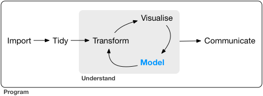

## The problem: a lack of convention in analysis and modeling packages

- Lack of conventions for how models are specified in calls to modeling functions
- Lack of conventions for what output looks like and how we work with it

## Fortunately, an emerging set of conventions on tidy principles

- this will be housed under [tidymodels](https://www.tidyverse.org/articles/2018/08/tidymodels-0-0-1/)
- [A draft set of tidy conventions for modeling packages](https://tidymodels.github.io/model-implementation-principles/index.html)
- But this is still largely under development

## Tools

- `broom` - models
- `infer` - hypothesis testing
- `corrr` - tidy analysis of correlations

## Additional modeling packages emerging

- `recipes` simplifies getting design matrices
- `tidybayes` and `tidyposterior`
- e.g., [`parsnip`](https://topepo.github.io/parsnip/), a tool to unify model specification across packages

## Today, some examples with `corrr`, `infer`, and `broom`

## Check for some installations

```r
install.packages(c("tidyverse", "corrr","infer","dotwhisker"))
```

## Load packages we will need

```r
library(tidyverse)
library(corrr)
library(infer)
library(dotwhisker)
```

## Tidy correlations with `corrr`

```r
#install.package('corrr')
library(corrr)
d <- correlate(mtcars)
d
```

```
## # A tibble: 11 x 12
##    rowname     mpg     cyl    disp      hp     drat      wt     qsec
##    <chr>     <dbl>   <dbl>   <dbl>   <dbl>    <dbl>   <dbl>    <dbl>
##  1 mpg      NA      -0.852  -0.848  -0.776   0.681   -0.868   0.419
##  2 cyl      -0.852  NA       0.902   0.832  -0.700    0.782  -0.591
##  3 disp     -0.848   0.902  NA       0.791  -0.710    0.888  -0.434
##  4 hp       -0.776   0.832   0.791  NA      -0.449    0.659  -0.708
##  5 drat      0.681  -0.700  -0.710  -0.449  NA       -0.712   0.0912
##  6 wt       -0.868   0.782   0.888   0.659  -0.712   NA      -0.175
##  7 qsec      0.419  -0.591  -0.434  -0.708   0.0912  -0.175  NA
##  8 vs        0.664  -0.811  -0.710  -0.723   0.440   -0.555   0.745
##  9 am        0.600  -0.523  -0.591  -0.243   0.713   -0.692  -0.230
## 10 gear      0.480  -0.493  -0.556  -0.126   0.700   -0.583  -0.213
## 11 carb     -0.551   0.527   0.395   0.750  -0.0908   0.428  -0.656
## # ... with 4 more variables: vs <dbl>, am <dbl>, gear <dbl>, carb <dbl>
```

## `corrr` makes exploring correlations easy + tidy

```r
# Filter rows to occasions in which cyl has a correlation of .7 or more with
# another variable.
d %>% filter(cyl > .7)
```

```
## # A tibble: 3 x 12
##   rowname    mpg   cyl   disp     hp   drat     wt   qsec     vs     am
##   <chr>    <dbl> <dbl>  <dbl>  <dbl>  <dbl>  <dbl>  <dbl>  <dbl>  <dbl>
## 1 disp    -0.848 0.902 NA      0.791 -0.710  0.888 -0.434 -0.710 -0.591
## 2 hp      -0.776 0.832  0.791 NA     -0.449  0.659 -0.708 -0.723 -0.243
## 3 wt      -0.868 0.782  0.888  0.659 -0.712 NA     -0.175 -0.555 -0.692
## # ... with 2 more variables: gear <dbl>, carb <dbl>
```

## `corrr` makes exploring correlations easy + tidy

```r
# Select the mpg, cyl and disp columns (and rowname)
d %>% select(rowname, mpg, cyl, disp)
```

```
## # A tibble: 11 x 4
##    rowname     mpg     cyl    disp
##    <chr>     <dbl>   <dbl>   <dbl>
##  1 mpg      NA      -0.852  -0.848
##  2 cyl      -0.852  NA       0.902
##  3 disp     -0.848   0.902  NA
##  4 hp       -0.776   0.832   0.791
##  5 drat      0.681  -0.700  -0.710
##  6 wt       -0.868   0.782   0.888
##  7 qsec      0.419  -0.591  -0.434
##  8 vs        0.664  -0.811  -0.710
##  9 am        0.600  -0.523  -0.591
## 10 gear      0.480  -0.493  -0.556
## 11 carb     -0.551   0.527   0.395
```

## Lots of operations you can do on a `cor_df`

- Internal changes (cor_df out)
  - shave() the upper or lower triangle (set to NA).
  - rearrange() the columns and rows based on correlation strengths.
- Reshape structure (tbl or cor_df out):
  - focus() on select columns and rows.
  - stretch() into a long format.
- Output/visualisations (console/plot out):
  - fashion() the correlations for pretty printing.
  - rplot() a shape for each correlation.
  - network_plot() a point for each variable, joined by paths for correlations.

## Tidy correlation output

```r
d %>%
  focus(mpg:drat, mirror = TRUE) %>%  # Focus only on mpg:drat
  shave() %>% # Remove the upper triangle
  fashion()   # Print in nice format
```

```
##   rowname  mpg  cyl disp   hp drat
## 1     mpg
## 2     cyl -.85
## 3    disp -.85  .90
## 4      hp -.78  .83  .79
## 5    drat  .68 -.70 -.71 -.45
```

## Visualize correlations

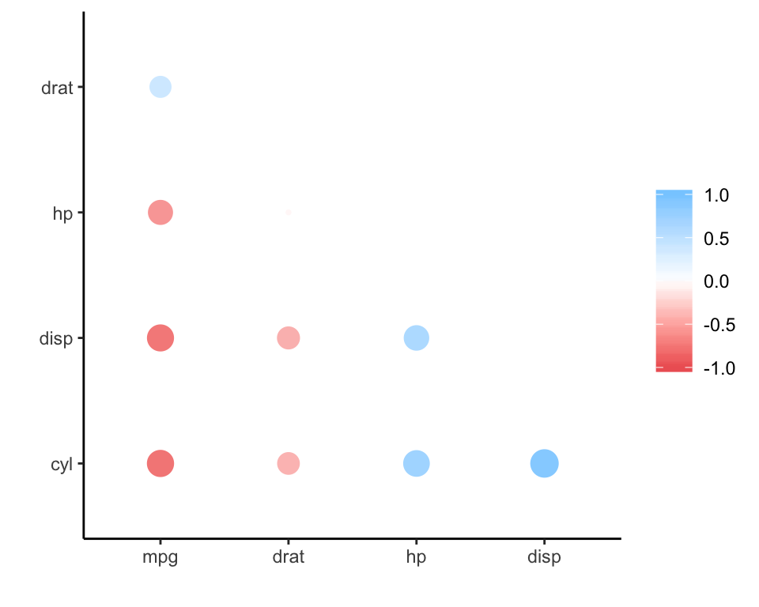

```r
d %>%
  focus(mpg:drat, mirror = TRUE) %>%
  rearrange(absolute = FALSE) %>%
  shave() %>%
  rplot()
```

## Using `infer` for tidy hypothesis testing

[`infer`](https://infer.netlify.com/reference/index.html) provides tidy tools for common hypothesis testing tasks including t-tests, chi-squared tests, etc. It’s really powerful for randomization/permutation inference and bootstrapping. For parametric tests, often ok to use base stats functions and then use `broom`, which we’ll review in the next section, to tidy them.

[figure not shown]

## Set up mtcars for example

Set up mtcars for the example analysis - mutate vars to factors

```r
mtcars <- as.data.frame(mtcars) %>%
  mutate(cyl = factor(cyl),
          vs = factor(vs),
          am = factor(am),
          gear = factor(gear),
          carb = factor(carb))
```

## `infer` functions

- `specify()` - specify response and explanatory variables, using formula
- `hypothesize()` - declare a null hypothesis (typically “independence”)
- `generate()` - generate permuatations/bootstraps
- `calculate()` - calculate summary statistics

## Things we can calculate() include

“mean”, “median”, “sd”, “prop”, “diff in means”, “diff in medians”, “diff in props”, “Chisq”, “F”, “slope”, “correlation”, “t”, “z”

## Difference in means: the old way

```r
t.out <-  t.test(mpg ~ am, data = mtcars)
t.out
```

```
##
##  Welch Two Sample t-test
##
## data:  mpg by am
## t = -3.7671, df = 18.332, p-value = 0.001374
## alternative hypothesis: true difference in means is not equal to 0
## 95 percent confidence interval:
##  -11.280194  -3.209684
## sample estimates:
## mean in group 0 mean in group 1
##        17.14737        24.39231
```

## Accessing stuff here is a chore

```r
t.out$statistic
```

```
##         t
## -3.767123
```

```r
t.out$p.value
```

```
## [1] 0.001373638
```

```r
t.out$estimate
```

```
## mean in group 0 mean in group 1
##        17.14737        24.39231
```

## Difference in means with `infer`

Use the `t_test()` function:

```r
mtcars %>%
  t_test(mpg ~ am, order = c("1", "0"), alternative = "less")
```

```
##   statistic     t_df   p_value alternative lower_ci upper_ci
## 1  3.767123 18.33225 0.9993132        less     -Inf 10.57662
```

## Or bootstrap it quickly and easily

Note the non-formula interface:

```r
mtcars %>%
  specify(response = mpg, explanatory = am) %>%
  generate(reps = 100, type = "bootstrap") %>%
  calculate(stat = "diff in means", order = c("1", "0"))
```

```
## # A tibble: 100 x 2
##    replicate  stat
##        <int> <dbl>
##  1         1  5.20
##  2         2  7.18
##  3         3  5.13
##  4         4  6.81
##  5         5  6.83
##  6         6  6.86
##  7         7  5.79
##  8         8  6.43
##  9         9 10.2
## 10        10  6.36
## # ... with 90 more rows
```

## `broom` - tidy up modeling output

[figure not shown]

## Tidying functions

- `tidy`: constructs a data frame that summarizes the model’s statistical findings. This includes coefficients and p-values for each term in a regression, per-cluster information in clustering applications, or per-test information for `multtest` functions.
- `augment`: add columns to the original data that was modeled. This includes predictions, residuals, and cluster assignments.
- `glance`: construct a concise *one-row* summary of the model. This typically contains values such as R^2, adjusted R^2, and residual standard error that are computed once for the entire model.

## Example

```r
lmfit <- lm(mpg ~ wt, mtcars)
lmfit
```

```
##
## Call:
## lm(formula = mpg ~ wt, data = mtcars)
##
## Coefficients:
## (Intercept)           wt
##      37.285       -5.344
```

```r
summary(lmfit)
```

```
##
## Call:
## lm(formula = mpg ~ wt, data = mtcars)
##
## Residuals:
##     Min      1Q  Median      3Q     Max
## -4.5432 -2.3647 -0.1252  1.4096  6.8727
##
## Coefficients:
##             Estimate Std. Error t value Pr(>|t|)
## (Intercept)  37.2851     1.8776  19.858  < 2e-16 ***
## wt           -5.3445     0.5591  -9.559 1.29e-10 ***
## ---
## Signif. codes:  0 '***' 0.001 '**' 0.01 '*' 0.05 '.' 0.1 ' ' 1
##
## Residual standard error: 3.046 on 30 degrees of freedom
## Multiple R-squared:  0.7528, Adjusted R-squared:  0.7446
## F-statistic: 91.38 on 1 and 30 DF,  p-value: 1.294e-10
```

## Tidy the output

Instead, you can use the `tidy` function, from the broom package, on the fit:

```r
library(broom)
tidy(lmfit)
```

```
##          term  estimate std.error statistic      p.value
## 1 (Intercept) 37.285126  1.877627 19.857575 8.241799e-19
## 2          wt -5.344472  0.559101 -9.559044 1.293959e-10
```

## Tidy the output

This gives you a data.frame representation. Note that the row names have been moved into a column called `term`, and the column names are simple and consistent (and can be accessed using `$`).

## Augment the output

Instead of viewing the coefficients, you might be interested in the fitted values and residuals for each of the original points in the regression. For this, use `augment`, which augments the original data with information from the model:

```r
augment(lmfit)
```

```
##     mpg    wt   .fitted   .se.fit     .resid       .hat   .sigma
## 1  21.0 2.620 23.282611 0.6335798 -2.2826106 0.04326896 3.067494
## 2  21.0 2.875 21.919770 0.5714319 -0.9197704 0.03519677 3.093068
## 3  22.8 2.320 24.885952 0.7359177 -2.0859521 0.05837573 3.072127
## 4  21.4 3.215 20.102650 0.5384424  1.2973499 0.03125017 3.088268
## 5  18.7 3.440 18.900144 0.5526562 -0.2001440 0.03292182 3.097722
## 6  18.1 3.460 18.793255 0.5552829 -0.6932545 0.03323551 3.095184
## 7  14.3 3.570 18.205363 0.5734244 -3.9053627 0.03544265 3.008664
## 8  24.4 3.190 20.236262 0.5386565  4.1637381 0.03127502 2.996697
## 9  22.8 3.150 20.450041 0.5397522  2.3499593 0.03140238 3.066058
## 10 19.2 3.440 18.900144 0.5526562  0.2998560 0.03292182 3.097435
## 11 17.8 3.440 18.900144 0.5526562 -1.1001440 0.03292182 3.090979
## 12 16.4 4.070 15.533127 0.7191881  0.8668731 0.05575179 3.093520
## 13 17.3 3.730 17.350247 0.6100029 -0.0502472 0.04010861 3.097938
## 14 15.2 3.780 17.083024 0.6236291 -1.8830236 0.04192052 3.077286
```

[output cut: 51 more lines]

Note that each of the new columns begins with a `.` (to avoid overwriting any of the original columns).

## Glance at the output

Finally, several summary statistics are computed for the entire regression, such as R^2 and the F-statistic. These can be accessed with the `glance` function:

```r
glance(lmfit)
```

```
##   r.squared adj.r.squared    sigma statistic      p.value df    logLik
## 1 0.7528328     0.7445939 3.045882  91.37533 1.293959e-10  2 -80.01471
##        AIC      BIC deviance df.residual
## 1 166.0294 170.4266 278.3219          30
```

## Generalized linear and non-linear models

These functions apply equally well to the output from `glm`:

```r
glmfit <- glm(am ~ wt, mtcars, family="binomial")
tidy(glmfit)
```

```
##          term estimate std.error statistic     p.value
## 1 (Intercept) 12.04037  4.509706  2.669879 0.007587858
## 2          wt -4.02397  1.436416 -2.801396 0.005088198
```

```r
augment(glmfit)
```

```
##    am    wt    .fitted   .se.fit      .resid         .hat    .sigma
## 1   1 2.620  1.4975684 0.9175750  0.63538540 0.1257790846 0.8033182
## 2   1 2.875  0.4714561 0.6761141  0.98483443 0.1081622613 0.7897742
## 3   1 2.320  2.7047594 1.2799233  0.35984584 0.0962849996 0.8101256
## 4   0 3.215 -0.8966937 0.6012064 -0.82717675 0.0743817517 0.7973421
## 5   0 3.440 -1.8020869 0.7486164 -0.55259722 0.0681219431 0.8061915
## 6   0 3.460 -1.8825663 0.7669573 -0.53230123 0.0674410149 0.8067014
## 7   0 3.570 -2.3252030 0.8778451 -0.43191437 0.0625221495 0.8089391
## 8   0 3.190 -0.7960945 0.5934948 -0.86291728 0.0754584628 0.7959095
## 9   0 3.150 -0.6351357 0.5855423 -0.92214813 0.0776201060 0.7933814
## 10  0 3.440 -1.8020869 0.7486164 -0.55259722 0.0681219431 0.8061915
## 11  0 3.440 -1.8020869 0.7486164 -0.55259722 0.0681219431 0.8061915
## 12  0 4.070 -4.3371880 1.4929683 -0.16117395 0.0283992283 0.8126022
## 13  0 3.730 -2.9690382 1.0606783 -0.31647306 0.0522749067 0.8109255
## 14  0 3.780 -3.1702367 1.1213659 -0.28683046 0.0486423376 0.8113337
```

[output cut: 51 more lines]

```r
glance(glmfit)
```

```
##   null.deviance df.null    logLik      AIC      BIC deviance df.residual
## 1      43.22973      31 -9.588042 23.17608 26.10756 19.17608          30
```

## Generalized linear and non-linear models

These functions also work on other fits, such as nonlinear models (`nls`):

```r
nlsfit <- nls(mpg ~ k / wt + b, mtcars, start=list(k=1, b=0))
tidy(nlsfit)
```

```
##   term  estimate std.error statistic      p.value
## 1    k 45.829488  4.249155 10.785554 7.639162e-12
## 2    b  4.386254  1.536418  2.854858 7.737378e-03
```

```r
augment(nlsfit, mtcars)
```

```
##     mpg cyl  disp  hp drat    wt  qsec vs am gear carb  .fitted
## 1  21.0   6 160.0 110 3.90 2.620 16.46  0  1    4    4 21.87843
## 2  21.0   6 160.0 110 3.90 2.875 17.02  0  1    4    4 20.32695
## 3  22.8   4 108.0  93 3.85 2.320 18.61  1  1    4    1 24.14034
## 4  21.4   6 258.0 110 3.08 3.215 19.44  1  0    3    1 18.64115
## 5  18.7   8 360.0 175 3.15 3.440 17.02  0  0    3    2 17.70878
## 6  18.1   6 225.0 105 2.76 3.460 20.22  1  0    3    1 17.63177
## 7  14.3   8 360.0 245 3.21 3.570 15.84  0  0    3    4 17.22365
## 8  24.4   4 146.7  62 3.69 3.190 20.00  1  0    4    2 18.75286
## 9  22.8   4 140.8  95 3.92 3.150 22.90  1  0    4    2 18.93530
## 10 19.2   6 167.6 123 3.92 3.440 18.30  1  0    4    4 17.70878
## 11 17.8   6 167.6 123 3.92 3.440 18.90  1  0    4    4 17.70878
## 12 16.4   8 275.8 180 3.07 4.070 17.40  0  0    3    3 15.64657
## 13 17.3   8 275.8 180 3.07 3.730 17.60  0  0    3    3 16.67298
## 14 15.2   8 275.8 180 3.07 3.780 18.00  0  0    3    3 16.51046
```

[output cut: 51 more lines]

```r
glance(nlsfit)
```

```
##     sigma isConv      finTol    logLik      AIC      BIC deviance
## 1 2.77405   TRUE 2.87694e-08 -77.02329 160.0466 164.4438 230.8606
##   df.residual
## 1          30
```

## Hypothesis testing

The `tidy` function can also be applied to `htest` objects, such as those output by popular built-in functions like `t.test`, `cor.test`, and `wilcox.test`.

```r
tt <- t.test(wt ~ am, mtcars)
tidy(tt)
```

```
##   estimate estimate1 estimate2 statistic     p.value parameter  conf.low
## 1 1.357895  3.768895     2.411  5.493905 6.27202e-06  29.23352 0.8525632
##   conf.high                  method alternative
## 1  1.863226 Welch Two Sample t-test   two.sided
```

## Hypothesis testing

Some cases might have fewer columns (for example, no confidence interval):

```r
wt <- wilcox.test(wt ~ am, mtcars)
tidy(wt)
```

```
##   statistic      p.value                                            method
## 1     230.5 4.347026e-05 Wilcoxon rank sum test with continuity correction
##   alternative
## 1   two.sided
```

## Hypothesis testing

Since the `tidy` output is already only one row, `glance` returns the same output:

```r
glance(tt)
```

```
##   estimate estimate1 estimate2 statistic     p.value parameter  conf.low
## 1 1.357895  3.768895     2.411  5.493905 6.27202e-06  29.23352 0.8525632
##   conf.high                  method alternative
## 1  1.863226 Welch Two Sample t-test   two.sided
```

```r
glance(wt)
```

```
##   statistic      p.value                                            method
## 1     230.5 4.347026e-05 Wilcoxon rank sum test with continuity correction
##   alternative
## 1   two.sided
```

## Tidy bootstrapping with `broom`

## Example: weight and mileage in `mtcars`

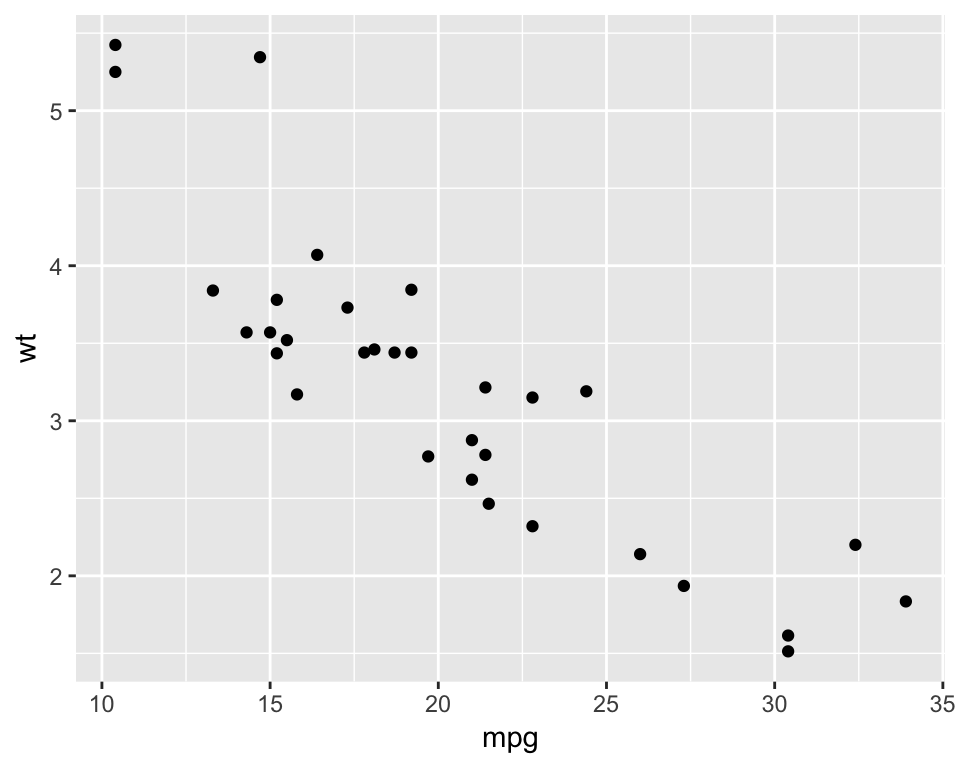

```r
library(ggplot2)
data(mtcars)
ggplot(mtcars, aes(mpg, wt)) + geom_point()
```

## Fit an nls model

```r
nlsfit <- nls(mpg ~ k / wt + b, mtcars, start=list(k=1, b=0))
summary(nlsfit)
```

```
##
## Formula: mpg ~ k/wt + b
##
## Parameters:
##   Estimate Std. Error t value Pr(>|t|)
## k   45.829      4.249  10.786 7.64e-12 ***
## b    4.386      1.536   2.855  0.00774 **
## ---
## Signif. codes:  0 '***' 0.001 '**' 0.01 '*' 0.05 '.' 0.1 ' ' 1
##
## Residual standard error: 2.774 on 30 degrees of freedom
##
## Number of iterations to convergence: 1
## Achieved convergence tolerance: 2.877e-08
```

## model

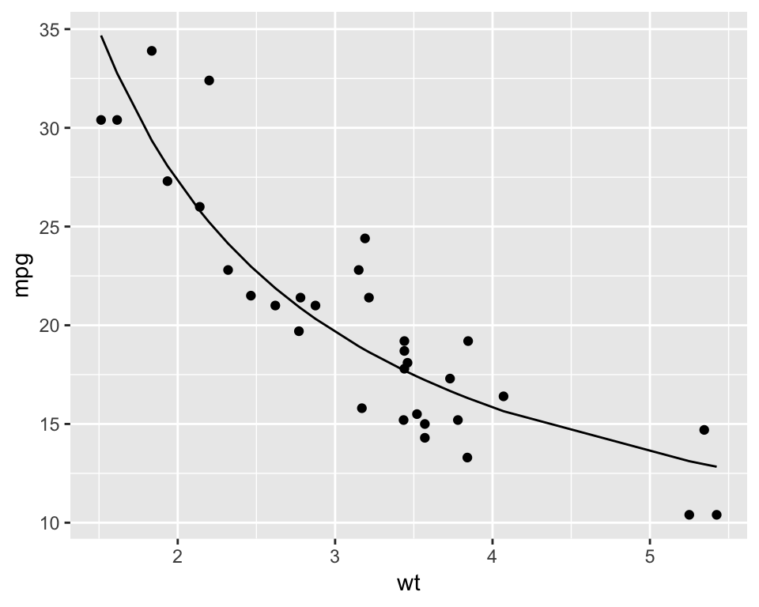

```r
ggplot(mtcars, aes(wt, mpg)) + geom_point() + geom_line(aes(y=predict(nlsfit)))
```

## We want to bootstrap the confidence intervals

```r
library(dplyr)
library(broom)
set.seed(2014)
bootnls <- mtcars %>% bootstrap(100) %>%
    do(tidy(nls(mpg ~ k / wt + b, ., start=list(k=1, b=0))))
```

## We get a clean `data.frame` that summarizes each replication

```r
bootnls
```

```
## # A tibble: 200 x 6
## # Groups:   replicate [100]
##    replicate term  estimate std.error statistic  p.value
##        <int> <chr>    <dbl>     <dbl>     <dbl>    <dbl>
##  1         1 k        46.6       4.03    11.6   1.34e-12
##  2         1 b         4.36      1.54     2.83  8.13e- 3
##  3         2 k        54.2       4.96    10.9   5.76e-12
##  4         2 b         1.00      1.90     0.530 6.00e- 1
##  5         3 k        43.3       3.56    12.1   4.22e-13
##  6         3 b         4.83      1.30     3.72  8.10e- 4
##  7         4 k        48.5       4.46    10.9   6.07e-12
##  8         4 b         3.51      1.69     2.08  4.64e- 2
##  9         5 k        52.6       5.66     9.29  2.47e-10
## 10         5 b         3.34      2.30     1.45  1.56e- 1
## # ... with 190 more rows
```

## use the percentile method to calculate uncertainty

```r
alpha = .05
bootnls %>% group_by(term) %>%
  summarize(low=quantile(estimate, alpha / 2),
  high=quantile(estimate, 1 - alpha / 2))
```

```
## # A tibble: 2 x 3
##   term     low  high
##   <chr>  <dbl> <dbl>
## 1 b      0.214  6.54
## 2 k     39.7   58.7
```

## Or you can use `augment` to visualize the uncertainty in the curve:

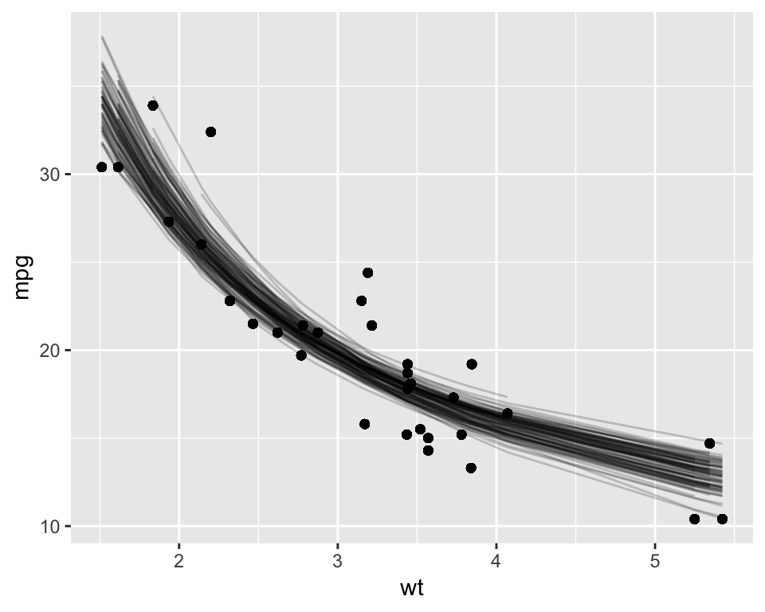

```r
bootnls_aug <- mtcars %>% bootstrap(100) %>%
    do(augment(nls(mpg ~ k / wt + b, ., start=list(k=1, b=0)), .))

ggplot(bootnls_aug, aes(wt, mpg)) + geom_point() +
    geom_line(aes(y=.fitted, group=replicate), alpha=.2)
```

## `broom` and “the secret weapon”

- [Gelman’s “secret weapon”](https://andrewgelman.com/2005/03/07/the_secret_weap/)
- Fit the same model repeatedly to different datasets
- Visualize a single predictor across each group

## Use `dotwhisker` and `broom` to use the secret weapon in a tidy way

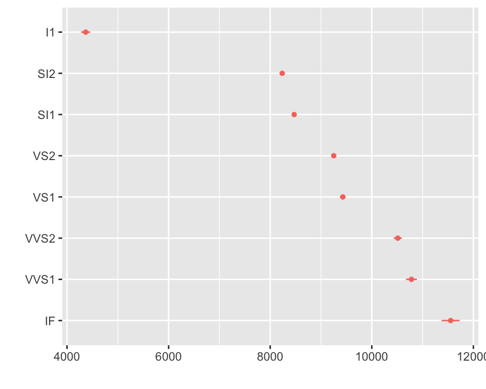

```r
# Estimate models across many samples, put results in a tidy data frame
by_clarity <- diamonds %>%
  group_by(clarity) %>%
  do(broom::tidy(lm(price ~ carat + cut + color, data = .))) %>%
  ungroup %>%
  rename(model = clarity)

# Generate a 'secret weapon' plot of the results of diamond size
secret_weapon(by_clarity, "carat")
```